# Introduction to rstac package

Rolf Simoes, Felipe Carvalho, and Gilberto Camara

2023-01-09

# About rstac

This document will introduce the concepts of the `rstac` package. `rstac` is an R client library for STAC that fully supports STAC API v1.0.0 and its earlier versions (>= v0.8.0).

The table shows the functions implemented by the `rstac` package according to the STAC API endpoints. For each endpoint, `rstac` has a specialized implementation.

| **STAC** endpoints | `rstac` functions | API version |
| --- | --- | --- |
| `/` | `stac()` | >= 0.9.0 |
| `/stac` | `stac()` | < 0.9.0 |
| `/collections` | `collections()` | >= 0.9.0 |
| `/collections/{collectionId}` | `collections(collection_id)` | >= 0.9.0 |
| `/collections/{collectionId}/items` | `items()` | >= 0.9.0 |
| `/collections/{collectionId}/items/{itemId}` | `items(feature_id)` | >= 0.9.0 |
| `/search` | `stac_search()` | >= 0.9.0 |
| `/stac/search` | `stac_search()` | < 0.9.0 |
| `/conformance` | `conformance()` | >= 0.9.0 |
| `/collections/{collectionId}/queryables` | `queryables()` | >= 1.0.0 |

The `rstac` package makes the requests explicitly. The `rstac` pipeline creates the endpoints with function concatenations and then requests them.

## Getting started

Let’s start by installing the `rstac` package:

```r
install.packages("rstac")
```

## Creating queries

This tutorial use the STAC API made available by the [Brazil Data Cube (BDC)](http://www.brazildatacube.org/en/home-page-2/) project. BDC is a research, development, and technological innovation project of the National Institute for Space Research (INPE), Brazil.

Let’s start by creating a query for the BDC catalog.

```r
s_obj <- stac("https://brazildatacube.dpi.inpe.br/stac/")
s_obj
```

```
#> ###RSTACQuery
#> - url: https://brazildatacube.dpi.inpe.br/stac/
#> - params:
#> - field(s): version, base_url, endpoint, params, verb, encode
```

The `RSTACQuery` object stores the metadata of the created query. This metadata can be accessed as a list element during query creation.

```r
s_obj$base_url
```

```
#> [1] "https://brazildatacube.dpi.inpe.br/stac/"
```

Endpoints are constructed through function concatenations provided by `rstac`. Some examples are shown below:

```r
s_obj |>
  collections()
```

```
#> ###RSTACQuery
#> - url: https://brazildatacube.dpi.inpe.br/stac/
#> - params:
#> - field(s): version, base_url, endpoint, params, verb, encode
```

```r
s_obj |>
  collections("S2-16D-2")
```

```
#> ###RSTACQuery
#> - url: https://brazildatacube.dpi.inpe.br/stac/
#> - params:
#>   - collection_id: S2-16D-2
#> - field(s): version, base_url, endpoint, params, verb, encode
```

```r
s_obj |>
  collections("S2-16D-2") |>
  items()
```

```
#> ###RSTACQuery
#> - url: https://brazildatacube.dpi.inpe.br/stac/
#> - params:
#>   - collection_id: S2-16D-2
#> - field(s): version, base_url, endpoint, params, verb, encode
```

```r
s_obj |>
  collections("S2-16D-2") |>
  items(feature_id = "S2-16D_V2_015011_20190117")
```

```
#> ###RSTACQuery
#> - url: https://brazildatacube.dpi.inpe.br/stac/
#> - params:
#>   - collection_id: S2-16D-2
#>   - feature_id: S2-16D_V2_015011_20190117
#> - field(s): version, base_url, endpoint, params, verb, encode
```

```r
s_obj |>
  stac_search(collections = c("CB4-16D-2", "S2-16D-2")) |>
  ext_query("bdc:tile" == "007004")
```

```
#> ###RSTACQuery
#> - url: https://brazildatacube.dpi.inpe.br/stac/
#> - params:
#>   - collections: CB4-16D-2,S2-16D-2
#>   - query: list(eq = "007004")
#> - field(s): version, base_url, endpoint, params, verb, encode
```

## Making requests

`rstac` package supports **GET** and **POST** HTTP methods. With future updates to the STAC specifications, it is intended to support other methods such as **PUT** and **DELETE**. In addition, it is possible to add more configuration options to the request, such as headers (`httr::add_headers()`) and cookies (`httr::set_cookies()`). These options are available in the `httr` package documentation in the [`config`](https://httr.r-lib.org/reference/config.html).

### HTTP GET: `get_request()`

```r
s_obj |>
  collections(collection_id = "CB4-16D-2") |>
  items() |>
  get_request()
```

```
#> ###STACItemCollection
#> - matched feature(s): 12740
#> - features (10 item(s) / 12730 not fetched):
#>   - CB4-16D_V2_000002_20230914
#>   - CB4-16D_V2_000003_20230914
#>   - CB4-16D_V2_001001_20230914
#>   - CB4-16D_V2_000004_20230914
#>   - CB4-16D_V2_001002_20230914
#>   - CB4-16D_V2_002000_20230914
#>   - CB4-16D_V2_001004_20230914
#>   - CB4-16D_V2_001003_20230914
#>   - CB4-16D_V2_002001_20230914
#>   - CB4-16D_V2_002003_20230914
#> - assets:
#> BAND13, BAND14, BAND15, BAND16, CLEAROB, CMASK, EVI, NDVI, PROVENANCE, TOTALOB, thumbnail
#> - item's fields:
#> assets, bbox, collection, geometry, id, links, properties, stac_extensions, stac_version, type
```

### HTTP POST: `post_request()`

```r
s_obj |>
  stac_search(
    collections = c("CB4-16D-2", "S2-16D-2"),
    datetime = "2021-01-01/2021-01-31",
    limit = 400) |>
  post_request()
```

```
#> ###STACItemCollection
#> - matched feature(s): 1886
#> - features (400 item(s) / 1486 not fetched):
#>   - CB4-16D_V2_006009_20210117
#>   - CB4-16D_V2_006006_20210117
#>   - CB4-16D_V2_006007_20210117
#>   - CB4-16D_V2_006008_20210117
#>   - CB4-16D_V2_006003_20210117
#>   - CB4-16D_V2_006004_20210117
#>   - CB4-16D_V2_006005_20210117
#>   - CB4-16D_V2_006001_20210117
#>   - CB4-16D_V2_006002_20210117
#>   - CB4-16D_V2_006000_20210117
#>   - ... with 390 more feature(s).
#> - assets:
#> B01, B02, B03, B04, B05, B06, B07, B08, B09, B11, B12, B8A, BAND13, BAND14, BAND15, BAND16, CLEAROB, CMASK, EVI, NBR, NDVI, PROVENANCE, SCL, TOTALOB, thumbnail
#> - item's fields:
#> assets, bbox, collection, geometry, id, links, properties, stac_extensions, stac_version, type
```

Example of providing an additional argument to HTTP verb in a request:

```r
s_obj |>
  stac_search(collections = c("CB4-16D-2", "S2-16D-2")) |>
  post_request(config = c(httr::add_headers("x-api-key" = "MY-KEY")))
```

```
#> ###STACItemCollection
#> - matched feature(s): 118204
#> - features (10 item(s) / 118194 not fetched):
#>   - CB4-16D_V2_000002_20230914
#>   - CB4-16D_V2_000003_20230914
#>   - CB4-16D_V2_001001_20230914
#>   - CB4-16D_V2_000004_20230914
#>   - CB4-16D_V2_001002_20230914
#>   - CB4-16D_V2_002000_20230914
#>   - CB4-16D_V2_001004_20230914
#>   - CB4-16D_V2_001003_20230914
#>   - CB4-16D_V2_002001_20230914
#>   - CB4-16D_V2_002003_20230914
#> - assets:
#> BAND13, BAND14, BAND15, BAND16, CLEAROB, CMASK, EVI, NDVI, PROVENANCE, TOTALOB, thumbnail
#> - item's fields:
#> assets, bbox, collection, geometry, id, links, properties, stac_extensions, stac_version, type
```

## Visualization of the documents

Each `rstac` object is mapped according to the endpoints of the STAC spec. In this way, each object has a different view. The format for viewing objects is in **Markdown**.

#### `STACCatalog` object

```r
s_obj |>
  get_request()
```

```
#> ###STACCatalog
#> - id: bdc
#> - description: Brazil Data Cube Catalog
#> - field(s): description, id, stac_version, links
```

#### `STACCollection` object

```r
s_obj |>
  collections("S2-16D-2") |>
  get_request()
```

```
#> ###STACCollection
#> - id: S2-16D-2
#> - title: Sentinel-2 - 10m - 16 days - v2
#> - description:
#> This datacube was generated with all available surface reflectance images processed using Sen2cor. The data is provided with 10 meters of spatial resolution, reprojected and cropped to BDC_SM grid Version 2 (BDC_SM V2), considering a temporal compositing function of 16 days using the Least Cloud …
#> - field(s):
#> id, stac_version, stac_extensions, title, version, deprecated, description, bdc:public, links, license, properties, extent, bdc:bands_quicklook, bdc:metadata, bdc:grs, bdc:tiles, bdc:composite_function, bdc:type, cube:dimensions, bdc:crs, bdc:temporal_composition
```

#### `STACItem` object

```r
s_obj |>
  collections("CB4-16D-2") |>
  items(feature_id = "CB4-16D_V2_000002_20230509") |>
  get_request()
```

```
#> ###STACItem
#> - id: CB4-16D_V2_000002_20230509
#> - collection: CB4-16D-2
#> - bbox: xmin: -75.61346, ymin: -5.31845, xmax: -71.54176, ymax: -1.25475
#> - datetime: 2023-05-09T00:00:00
#> - assets:
#> BAND13, BAND14, BAND15, BAND16, CLEAROB, CMASK, EVI, NDVI, PROVENANCE, TOTALOB, thumbnail
#> - item's fields:
#> assets, bbox, collection, geometry, id, links, properties, stac_extensions, stac_version, type
```

#### `STACItemCollection` object

```r
s_obj |>
  stac_search(collections = c("CB4_64_16D_STK", "S2-16D-2")) |>
  get_request()
```

```
#> ###STACItemCollection
#> - matched feature(s): 105465
#> - features (10 item(s) / 105455 not fetched):
#>   - S2-16D_V2_001014_20220930
#>   - S2-16D_V2_002011_20220930
#>   - S2-16D_V2_002012_20220930
#>   - S2-16D_V2_002013_20220930
#>   - S2-16D_V2_002014_20220930
#>   - S2-16D_V2_002015_20220930
#>   - S2-16D_V2_002016_20220930
#>   - S2-16D_V2_003011_20220930
#>   - S2-16D_V2_003012_20220930
#>   - S2-16D_V2_003013_20220930
#> - assets:
#> B01, B02, B03, B04, B05, B06, B07, B08, B09, B11, B12, B8A, CLEAROB, EVI, NBR, NDVI, PROVENANCE, SCL, TOTALOB, thumbnail
#> - item's fields:
#> assets, bbox, collection, geometry, id, links, properties, stac_extensions, stac_version, type
```

Besides, the `rstac` package provides several auxiliary functions for `STACItem` and `STACItemCollection` objects. These auxiliary functions operate at the item or asset level. Functions dedicated to items have the prefix `items_`. Otherwise, asset-oriented functions have the prefix `assets_`

## Items functions

The `STACItemCollection` object have some facilitating functions to manipulate/extract information, for example:

- **`items_fields()`:** Lists fields names inside an item.
- **`items_filter()`:** Performs a filter by items according to expressions operating on the properties of a `STACItemCollection` object.
- **`items_fetch()`:** Performs the pagination of items.
- **`items_length()`:** Returns the number of items in an object.
- **`items_matched()`:** Returns the number of items matching the search criteria.
- **`items_assets()`:** Returns the assets name from `STACItemCollection` and `STACItem` objects.

It is interesting to verify the fields of items before filtering:

```r
s_obj |>
  stac_search(
    collections = "CB4-16D-2",
    datetime = "2019-01-01/2019-12-31",
    limit = 100) |>
  post_request() |>
  items_fields(field = "properties")
```

```
#>  [1] "bdc:tiles"      "created"        "datetime"       "end_datetime"
#>  [5] "eo:bands"       "eo:cloud_cover" "eo:gsd"         "instruments"
#>  [9] "platform"       "start_datetime" "updated"
```

Let’s filter items that have the percentage of clouds smaller than 10%:

```r
s_obj |>
  stac_search(
    collections = "CB4-16D-2",
    datetime = "2019-01-01/2019-12-31",
    limit = 100) |>
  post_request() |>
  items_filter(properties$`eo:cloud_cover` < 10)
```

```
#> ###STACItemCollection
#> - matched feature(s): 1656
#> - features (55 item(s) / 1601 not fetched):
#>   - CB4-16D_V2_006009_20191219
#>   - CB4-16D_V2_006006_20191219
#>   - CB4-16D_V2_006007_20191219
#>   - CB4-16D_V2_006008_20191219
#>   - CB4-16D_V2_006004_20191219
#>   - CB4-16D_V2_006005_20191219
#>   - CB4-16D_V2_007003_20191219
#>   - CB4-16D_V2_007004_20191219
#>   - CB4-16D_V2_007005_20191219
#>   - CB4-16D_V2_007006_20191219
#>   - ... with 45 more feature(s).
#> - assets:
#> BAND13, BAND14, BAND15, BAND16, CLEAROB, CMASK, EVI, NDVI, PROVENANCE, TOTALOB, thumbnail
#> - item's fields:
#> assets, bbox, collection, geometry, id, links, properties, stac_extensions, stac_version, type
```

Number of items returned in the query (in this case equal to the limit defined as parameter):

```r
s_obj |>
  stac_search(
    collections = "CB4-16D-2",
    datetime = "2019-01-01/2019-12-31",
    limit = 100) |>
  post_request() |>
  items_length()
```

```
#> [1] 100
```

Number of matched items in the query:

```r
s_obj |>
  stac_search(
    collections = "CB4-16D-2",
    datetime = "2019-01-01/2019-12-31",
    limit = 100) |>
  post_request() |>
  items_matched()
```

```
#> [1] 1656
```

Paginating all items that were matched in the query:

```r
items_fetched <- s_obj |>
  stac_search(
    collections = "CB4-16D-2",
    datetime = "2019-01-01/2019-12-31",
    limit = 500) |>
  post_request() |>
  items_fetch(progress = FALSE)

items_fetched
```

```
#> ###STACItemCollection
#> - matched feature(s): 1656
#> - features (1656 item(s) / 0 not fetched):
#>   - CB4-16D_V2_006009_20191219
#>   - CB4-16D_V2_006006_20191219
#>   - CB4-16D_V2_006007_20191219
#>   - CB4-16D_V2_006008_20191219
#>   - CB4-16D_V2_006003_20191219
#>   - CB4-16D_V2_006004_20191219
#>   - CB4-16D_V2_006005_20191219
#>   - CB4-16D_V2_006001_20191219
#>   - CB4-16D_V2_006002_20191219
#>   - CB4-16D_V2_006000_20191219
#>   - ... with 1646 more feature(s).
#> - assets:
#> BAND13, BAND14, BAND15, BAND16, CLEAROB, CMASK, EVI, NDVI, PROVENANCE, TOTALOB, thumbnail
#> - item's fields:
#> assets, bbox, collection, geometry, id, links, properties, stac_extensions, stac_version, type
```

```r
items_length(items_fetched)
```

```
#> [1] 1656
```

Listing the assets of the retrieved items:

```r
items_assets(items_fetched)
```

```
#>  [1] "BAND13"     "BAND14"     "BAND15"     "BAND16"     "CLEAROB"
#>  [6] "CMASK"      "EVI"        "NDVI"       "PROVENANCE" "TOTALOB"
#> [11] "thumbnail"
```

## Assets functions

- **`assets_download()`:** Downloads the assets provided by the STAC API.
- **`assets_url()`:** Returns a character vector with each asset href. For the URL you can add the GDAL library drivers for the following schemes:
  - HTTP/HTTPS files;
  - S3 (AWS S3);
  - GS (Google Cloud Storage).
- **`assets_select()`:** Selects the assets of each item by its name.
- **`assets_rename()`:** Rename each asset using a named list or a function.

Listing the assets names of all items:

```r
s_obj |>
  stac_search(
    collections = "CB4-16D-2",
    datetime = "2019-01-01/2019-12-31",
    limit = 10) |>
  post_request() |>
  items_assets()
```

```
#>  [1] "BAND13"     "BAND14"     "BAND15"     "BAND16"     "CLEAROB"
#>  [6] "CMASK"      "EVI"        "NDVI"       "PROVENANCE" "TOTALOB"
#> [11] "thumbnail"
```

Selecting assets that have names `"BAND14"` and `"NDVI"`

```r
selected_assets <- s_obj |>
  stac_search(
    collections = "CB4-16D-2",
    datetime = "2019-01-01/2019-12-31",
    limit = 10) |>
  post_request() |>
  assets_select(asset_names = c("BAND14", "NDVI"))
```

```r
items_assets(selected_assets)
```

```
#> [1] "BAND14" "NDVI"
```

Listing asset urls from the selected bands:

```r
selected_assets |>
  assets_url()
```

```
#>  [1] "https://brazildatacube.dpi.inpe.br/cubes/composed/cb4-16d/v2/006/009/2019/12/19/CB4-16D_V2_006009_20191219_BAND14.tif"
#>  [2] "https://brazildatacube.dpi.inpe.br/cubes/composed/cb4-16d/v2/006/006/2019/12/19/CB4-16D_V2_006006_20191219_BAND14.tif"
#>  [3] "https://brazildatacube.dpi.inpe.br/cubes/composed/cb4-16d/v2/006/007/2019/12/19/CB4-16D_V2_006007_20191219_BAND14.tif"
#>  [4] "https://brazildatacube.dpi.inpe.br/cubes/composed/cb4-16d/v2/006/008/2019/12/19/CB4-16D_V2_006008_20191219_BAND14.tif"
#>  [5] "https://brazildatacube.dpi.inpe.br/cubes/composed/cb4-16d/v2/006/003/2019/12/19/CB4-16D_V2_006003_20191219_BAND14.tif"
#>  [6] "https://brazildatacube.dpi.inpe.br/cubes/composed/cb4-16d/v2/006/004/2019/12/19/CB4-16D_V2_006004_20191219_BAND14.tif"
#>  [7] "https://brazildatacube.dpi.inpe.br/cubes/composed/cb4-16d/v2/006/005/2019/12/19/CB4-16D_V2_006005_20191219_BAND14.tif"
#>  [8] "https://brazildatacube.dpi.inpe.br/cubes/composed/cb4-16d/v2/006/001/2019/12/19/CB4-16D_V2_006001_20191219_BAND14.tif"
#>  [9] "https://brazildatacube.dpi.inpe.br/cubes/composed/cb4-16d/v2/006/002/2019/12/19/CB4-16D_V2_006002_20191219_BAND14.tif"
#> [10] "https://brazildatacube.dpi.inpe.br/cubes/composed/cb4-16d/v2/006/000/2019/12/19/CB4-16D_V2_006000_20191219_BAND14.tif"
#> [11] "https://brazildatacube.dpi.inpe.br/cubes/composed/cb4-16d/v2/006/009/2019/12/19/CB4-16D_V2_006009_20191219_NDVI.tif"
#> [12] "https://brazildatacube.dpi.inpe.br/cubes/composed/cb4-16d/v2/006/006/2019/12/19/CB4-16D_V2_006006_20191219_NDVI.tif"
#> [13] "https://brazildatacube.dpi.inpe.br/cubes/composed/cb4-16d/v2/006/007/2019/12/19/CB4-16D_V2_006007_20191219_NDVI.tif"
#> [14] "https://brazildatacube.dpi.inpe.br/cubes/composed/cb4-16d/v2/006/008/2019/12/19/CB4-16D_V2_006008_20191219_NDVI.tif"
#> [15] "https://brazildatacube.dpi.inpe.br/cubes/composed/cb4-16d/v2/006/003/2019/12/19/CB4-16D_V2_006003_20191219_NDVI.tif"
#> [16] "https://brazildatacube.dpi.inpe.br/cubes/composed/cb4-16d/v2/006/004/2019/12/19/CB4-16D_V2_006004_20191219_NDVI.tif"
#> [17] "https://brazildatacube.dpi.inpe.br/cubes/composed/cb4-16d/v2/006/005/2019/12/19/CB4-16D_V2_006005_20191219_NDVI.tif"
#> [18] "https://brazildatacube.dpi.inpe.br/cubes/composed/cb4-16d/v2/006/001/2019/12/19/CB4-16D_V2_006001_20191219_NDVI.tif"
#> [19] "https://brazildatacube.dpi.inpe.br/cubes/composed/cb4-16d/v2/006/002/2019/12/19/CB4-16D_V2_006002_20191219_NDVI.tif"
#> [20] "https://brazildatacube.dpi.inpe.br/cubes/composed/cb4-16d/v2/006/000/2019/12/19/CB4-16D_V2_006000_20191219_NDVI.tif"
```

Renaming assets using the pattern `<old-name> = <new-name>`

```r
renamed_assets <- selected_assets |>
  assets_rename(BAND14 = "B14")
renamed_assets
```

```
#> ###STACItemCollection
#> - matched feature(s): 1656
#> - features (10 item(s) / 1646 not fetched):
#>   - CB4-16D_V2_006009_20191219
#>   - CB4-16D_V2_006006_20191219
#>   - CB4-16D_V2_006007_20191219
#>   - CB4-16D_V2_006008_20191219
#>   - CB4-16D_V2_006003_20191219
#>   - CB4-16D_V2_006004_20191219
#>   - CB4-16D_V2_006005_20191219
#>   - CB4-16D_V2_006001_20191219
#>   - CB4-16D_V2_006002_20191219
#>   - CB4-16D_V2_006000_20191219
#> - assets: B14, NDVI
#> - item's fields:
#> assets, bbox, collection, geometry, id, links, properties, stac_extensions, stac_version, type
```

In the `assets` field of the output it can be seen that the asset’s name has changed. It is also possible to check the asset names using the `items_assets()` function.

```r
items_assets(renamed_assets)
```

```
#> [1] "B14"  "NDVI"
```

## Asset preview

`rstac` also provides a helper function to plot preview assets (e.g. thumbnail and quicklook).

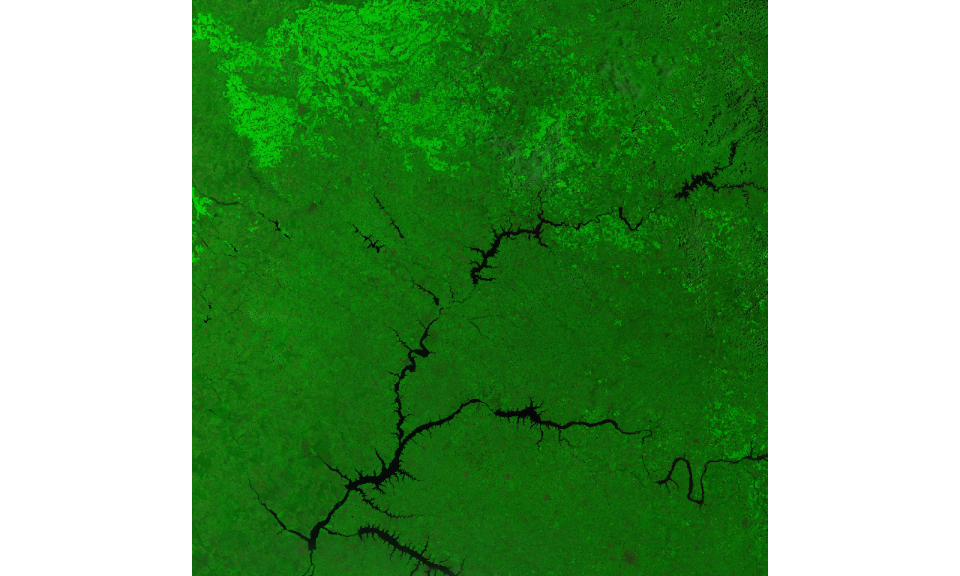

```r
second_item <- items_fetched$features[[2]]
second_item |>
  assets_url(asset_names = "thumbnail") |>
  preview_plot()
```

Here, we selected the second item of `items_fetched`’s features and plotted its `thumbnail` asset.

# Conclusion

The `rstac` package can be useful for querying and working with satellite imagery data from STAC APIs. It offers a simple interface for searching STAC items, exploring the results, and working with assets. Additional functionalities include reading and plotting preview images. This tutorial has provided a short introduction on how to use the package. For more about CQL2 in `rstac`, type the command `?ext_filter`.